# Dalex_R_Practice

m.oka

6/11/2020

# 5 Data sets and models

## 5.1 Sinking of the RMS Titanic

- ライブラリインポート

```r
library('DALEX')
```

- Titanic Data確認
- DALEXにはtitanicデータセットが入っている。

```r
head(titanic, 2)
```

```
##   gender age class    embarked       country  fare sibsp parch survived
## 1   male  42   3rd Southampton United States  7.11     0     0       no
## 2   male  13   3rd Southampton United States 20.05     0     2       no
```

### 5.1.1 Data exploration

- データ構造確認

```r
summary(titanic)
```

```
##     gender          age                       class            embarked
##  female: 489   Min.   : 0.1667   1st             :324   Belfast    : 197
##  male  :1718   1st Qu.:22.0000   2nd             :284   Cherbourg  : 271
##                Median :29.0000   3rd             :709   Queenstown : 123
##                Mean   :30.4367   deck crew       : 66   Southampton:1616
##                3rd Qu.:38.0000   engineering crew:324
##                Max.   :74.0000   restaurant staff: 69
##                NA's   :2         victualling crew:431
##           country          fare             sibsp            parch
##  England      :1125   Min.   :  0.000   Min.   :0.0000   Min.   :0.0000
##  United States: 264   1st Qu.:  0.000   1st Qu.:0.0000   1st Qu.:0.0000
##  Ireland      : 137   Median :  7.151   Median :0.0000   Median :0.0000
##  Sweden       : 105   Mean   : 19.773   Mean   :0.2972   Mean   :0.2294
##  Lebanon      :  71   3rd Qu.: 20.111   3rd Qu.:0.0000   3rd Qu.:0.0000
##  (Other)      : 424   Max.   :512.061   Max.   :8.0000   Max.   :9.0000
##  NA's         :  81   NA's   :26        NA's   :10       NA's   :10
##  survived
##  no :1496
##  yes: 711
##
##
##
##
##
```

- 欠損値補完

```r
# age
titanic$age[is.na(titanic$age)] = 30 # NAに30を入れる
# country
titanic$country <- as.character(titanic$country) # データ型を文字列に
titanic$country[is.na(titanic$country)] = 'X' # NAに'X'を代入
titanic$country <- factor(titanic$country) # country列のベクトル化
# fare：クラスの平均値で補完
titanic$fare[is.na(titanic$fare) & titanic$class == '1st'] = 89
titanic$fare[is.na(titanic$fare) & titanic$class == '2nd'] = 22
titanic$fare[is.na(titanic$fare) & titanic$class == '3rd'] = 13
# sibsp、parch：0で補完
titanic$sibsp[is.na(titanic$sibsp)] = 0
titanic$parch[is.na(titanic$parch)] = 0
```

- 欠損値補完がされたかを確認

```r
summary(titanic)
```

```
##     gender          age                       class            embarked
##  female: 489   Min.   : 0.1667   1st             :324   Belfast    : 197
##  male  :1718   1st Qu.:22.0000   2nd             :284   Cherbourg  : 271
##                Median :29.0000   3rd             :709   Queenstown : 123
##                Mean   :30.4363   deck crew       : 66   Southampton:1616
##                3rd Qu.:38.0000   engineering crew:324
##                Max.   :74.0000   restaurant staff: 69
##                                  victualling crew:431
##           country          fare             sibsp            parch
##  England      :1125   Min.   :  0.000   Min.   :0.0000   Min.   :0.0000
##  United States: 264   1st Qu.:  0.000   1st Qu.:0.0000   1st Qu.:0.0000
##  Ireland      : 137   Median :  7.151   Median :0.0000   Median :0.0000
##  Sweden       : 105   Mean   : 19.992   Mean   :0.2959   Mean   :0.2284
##  X            :  81   3rd Qu.: 21.000   3rd Qu.:0.0000   3rd Qu.:0.0000
##  Lebanon      :  71   Max.   :512.061   Max.   :8.0000   Max.   :9.0000
##  (Other)      : 424
##  survived
##  no :1496
##  yes: 711
##
##
##
##
##
```

### 5.1.2 Logistic regression model

- survivedがyesを予測するモデルを作成

```r
library('rms')
set.seed(1313)
titanic_lmr_v6 <- lrm(survived == 'yes' ~ gender + rcs(age) + class + sibsp + parch + fare + embarked, titanic)
titanic_lmr_v6
```

```
## Logistic Regression Model
##
##  lrm(formula = survived == "yes" ~ gender + rcs(age) + class +
##      sibsp + parch + fare + embarked, data = titanic)
##
##                         Model Likelihood     Discrimination    Rank Discrim.
##                            Ratio Test           Indexes           Indexes
##  Obs           2207    LR chi2     752.06    R2       0.404    C       0.817
##   FALSE        1496    d.f.            17    g        1.647    Dxy     0.635
##   TRUE          711    Pr(> chi2) <0.0001    gr       5.191    gamma   0.636
##  max |deriv| 0.0001                          gp       0.282    tau-a   0.277
##                                              Brier    0.146
##
##                         Coef    S.E.   Wald Z Pr(>|Z|)
##  Intercept               4.5746 0.5480   8.35 <0.0001
##  gender=male            -2.7687 0.1586 -17.45 <0.0001
##  age                    -0.1180 0.0221  -5.35 <0.0001
##  age'                    0.6313 0.1628   3.88 0.0001
##  age''                  -2.6583 0.7840  -3.39 0.0007
##  age'''                  2.8977 1.0130   2.86 0.0042
##  class=2nd              -1.1390 0.2501  -4.56 <0.0001
##  class=3rd              -2.0627 0.2490  -8.28 <0.0001
##  class=deck crew         1.0672 0.3498   3.05 0.0023
##  class=engineering crew -0.9702 0.2648  -3.66 0.0002
##  class=restaurant staff -3.1712 0.6583  -4.82 <0.0001
##  class=victualling crew -1.0877 0.2596  -4.19 <0.0001
##  sibsp                  -0.4504 0.1006  -4.48 <0.0001
##  parch                  -0.0871 0.0987  -0.88 0.3776
##  fare                    0.0014 0.0020   0.70 0.4842
##  embarked=Cherbourg      0.7881 0.2836   2.78 0.0055
##  embarked=Queenstown     0.2745 0.3409   0.80 0.4208
##  embarked=Southampton    0.2343 0.2119   1.11 0.2689
##
```

### 5.1.3 Random forest model

```r
library("randomForest")
set.seed(1313)
```

- ランダムフォレスト（説明変数７つ）モデル作成

```r
titanic_rf_v6 <- randomForest(survived ~ class + gender + age + sibsp +
         parch + fare + embarked, data = titanic)
titanic_rf_v6
```

```
##
## Call:
##  randomForest(formula = survived ~ class + gender + age + sibsp +      parch + fare + embarked, data = titanic)
##                Type of random forest: classification
##                      Number of trees: 500
## No. of variables tried at each split: 2
##
##         OOB estimate of  error rate: 18.62%
## Confusion matrix:
##       no yes class.error
## no  1393 103  0.06885027
## yes  308 403  0.43319269
```

- ランダムフォレスト（説明変数３つ）モデル作成

```r
titanic_rf_v3 <- randomForest(survived ~ class + gender + age, data = titanic)
titanic_rf_v3
```

```
##
## Call:
##  randomForest(formula = survived ~ class + gender + age, data = titanic)
##                Type of random forest: classification
##                      Number of trees: 500
## No. of variables tried at each split: 1
##
##         OOB estimate of  error rate: 21.02%
## Confusion matrix:
##       no yes class.error
## no  1367 129  0.08622995
## yes  335 376  0.47116737
```

### 今後の説明はすべてtitanic_rf_v6のため、5.1.4, 5.1.5は省略

### 5.1.6 Model predictions

- johny_dのデータを作成

```r
johny_d <- data.frame(
            class = factor("1st", levels = c("1st", "2nd", "3rd", "deck crew",
                        "engineering crew", "restaurant staff", "victualling crew")),
            gender = factor("male", levels = c("female", "male")),
            age = 8,
            sibsp = 0,
            parch = 0,
            fare = 72,
            embarked = factor("Southampton", levels = c("Belfast",
                        "Cherbourg","Queenstown","Southampton"))
)
```

- ロジスティック回帰で予測

```r
pred_lmr <- predict(titanic_lmr_v6, johny_d, type = 'fitted')
pred_lmr
```

```
##         1
## 0.7677036
```

```r
predict(titanic_rf_v6, johny_d ,type = 'prob')
```

```
##      no   yes
## 1 0.578 0.422
## attr(,"class")
## [1] "matrix" "votes"
```

### 5.1.7 Model adapters

- 後に使うhenryデータを作成

```r
henry <- data.frame(
         class = factor("1st", levels = c("1st", "2nd", "3rd", "deck crew",
                     "engineering crew", "restaurant staff", "victualling crew")),
         gender = factor("male", levels = c("female", "male")),
         age = 47,
         sibsp = 0,
         parch = 0,
         fare = 25,
         embarked = factor("Cherbourg", levels = c("Belfast",
                           "Cherbourg","Queenstown","Southampton"))
)
henry
```

```
##   class gender age sibsp parch fare  embarked
## 1   1st   male  47     0     0   25 Cherbourg
```

# 7 Break-down Plots for Additive Attributions

## 7.5 Code snippets for R

- モデルの呼び出し

```r
library('randomForest')
explain_rf_v6 <- archivist::aread('pbiecek/models/6ed54')
explain_rf_v6
```

```
## Model label:  Random Forest
## Model class:  randomForest.formula,randomForest
## Data head  :
##   gender age class    embarked       country  fare sibsp parch
## 1   male  42   3rd Southampton United States  7.11     0     0
## 2   male  13   3rd Southampton United States 20.05     0     2
```

- データ呼び出し

```r
library('DALEX')
henry <- archivist::aread('pbiecek/models/a6538')
henry
```

```
##   class gender age sibsp parch fare  embarked
## 1   1st   male  47     0     0   25 Cherbourg
```

- 予測

```r
predict(explain_rf_v6, henry)
```

```
## [1] 0.254
```

### 7.5.1 Basic use of the variable_attribution() function

- DALEX::variable_attribution()でBDPlotを行う

```r
# 重要度計算
bd_rf <- variable_attribution(explain_rf_v6, new_observation = henry, type = 'break_down')
bd_rf
```

```
##                                     contribution
## Random Forest: intercept                   0.235
## Random Forest: class = 1st                 0.168
## Random Forest: gender = male              -0.127
## Random Forest: embarked = Cherbourg        0.098
## Random Forest: age = 47                   -0.083
## Random Forest: fare = 25                  -0.011
## Random Forest: sibsp = 0                  -0.024
## Random Forest: parch = 0                  -0.002
## Random Forest: prediction                  0.254
```

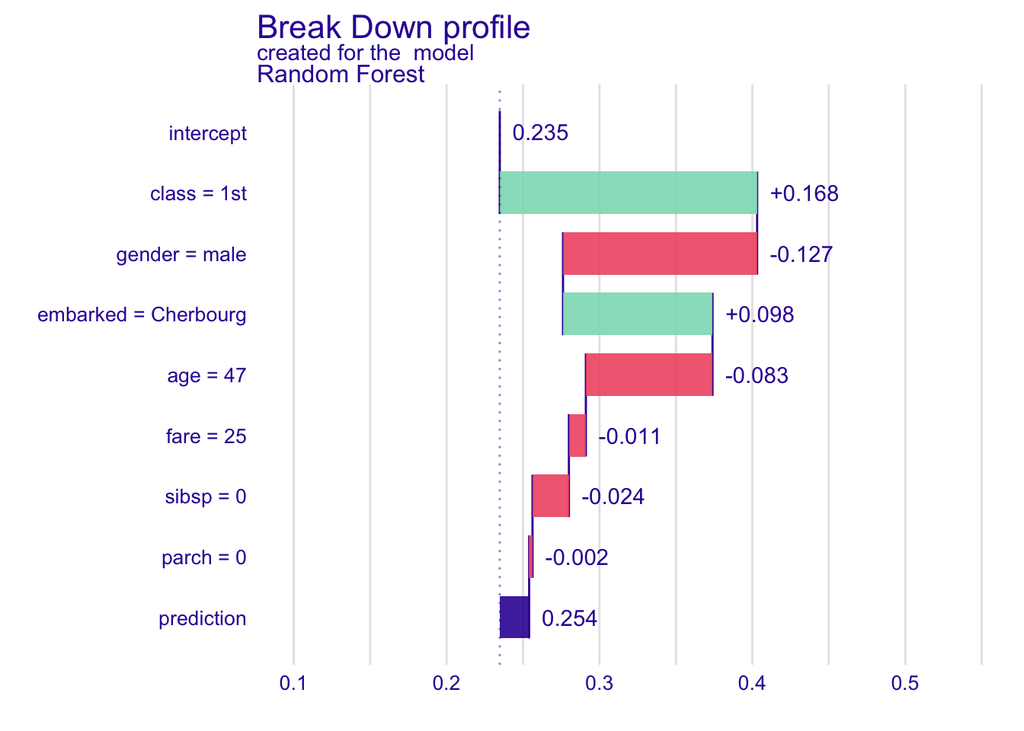

```r
# plotする
plot(bd_rf)
```

### 7.5.2 Advanced use of the variable_attribution() function

- 順序をorderで指定

```r
bd_rf_order <- variable_attribution(explain_rf_v6, new_observation = henry, type = 'break_down', order = c('class', 'age', 'gender', 'fare', 'parch', 'sibsp', 'embarked'))
bd_rf_order
```

```
##                                     contribution
## Random Forest: intercept                   0.235
## Random Forest: class = 1st                 0.168
## Random Forest: age = 47                   -0.013
## Random Forest: gender = male              -0.146
## Random Forest: fare = 25                  -0.049
## Random Forest: parch = 0                   0.000
## Random Forest: sibsp = 0                  -0.020
## Random Forest: embarked = Cherbourg        0.079
## Random Forest: prediction                  0.254
```

- 表示する説明変数を３つに絞ってplot

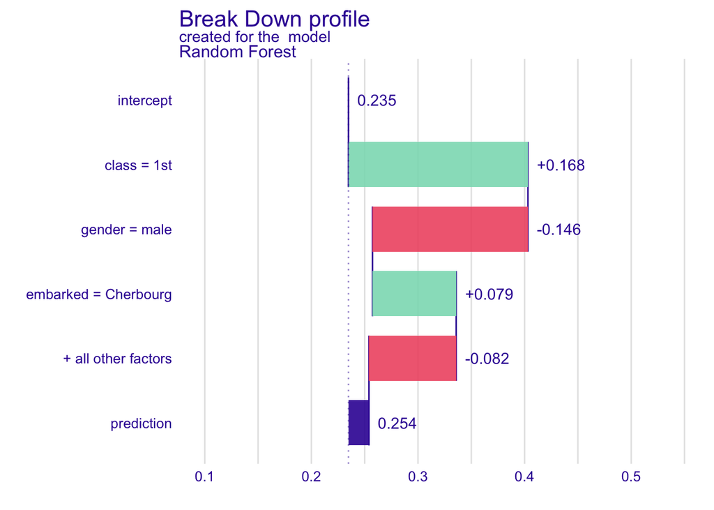

```r
plot(bd_rf_order, max_features = 3)
```

# 8 Break-down Plots for Interactions (iBreak-down Plots)

## 8.5 Code snippets for R

- モデルの呼び出し

```r
library('randomForest')
explain_rf_v6 <- archivist::aread('pbiecek/models/6ed54')
explain_rf_v6
```

```
## Model label:  Random Forest
## Model class:  randomForest.formula,randomForest
## Data head  :
##   gender age class    embarked       country  fare sibsp parch
## 1   male  42   3rd Southampton United States  7.11     0     0
## 2   male  13   3rd Southampton United States 20.05     0     2
```

- データ呼び出し

```r
library('DALEX')
henry <- archivist::aread('pbiecek/models/a6538')
henry
```

```
##   class gender age sibsp parch fare  embarked
## 1   1st   male  47     0     0   25 Cherbourg
```

- 予測

```r
predict(explain_rf_v6, henry)
```

```
## [1] 0.254
```

- DALEX::variable_attribution()でiBDPlotを行う

```r
library('DALEX')
bdi_rf <- variable_attribution(explain_rf_v6, new_observation = henry, type = 'break_down_interactions')
bdi_rf
```

```
##                                     contribution
## Random Forest: intercept                   0.235
## Random Forest: class = 1st                 0.168
## Random Forest: gender = male              -0.127
## Random Forest: embarked = Cherbourg        0.098
## Random Forest: age = 47                   -0.083
## Random Forest: fare = 25                  -0.011
## Random Forest: sibsp = 0                  -0.024
## Random Forest: parch = 0                  -0.002
## Random Forest: prediction                  0.254
```

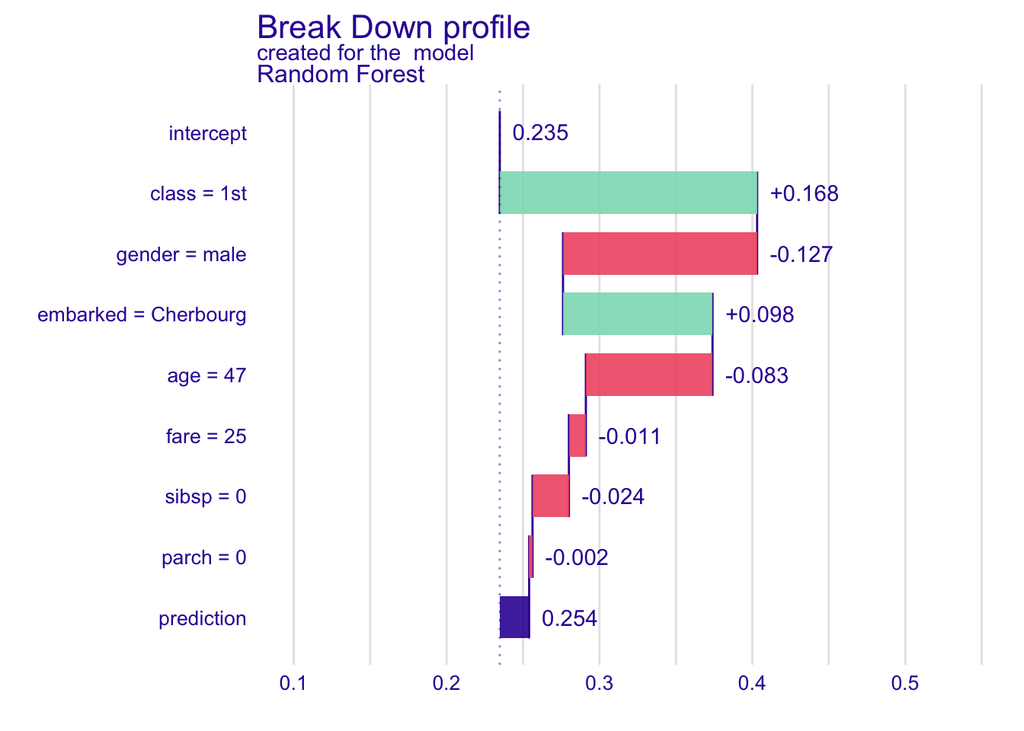

```r
plot(bdi_rf)
```

# 9 Shapley Additive Explanations (SHAP) and Average Variable Attributions

## 9.5 Code snippets for R

- モデルの呼び出し

```r
library('randomForest')
explain_rf_v6 <- archivist::aread('pbiecek/models/6ed54')
explain_rf_v6
```

```
## Model label:  Random Forest
## Model class:  randomForest.formula,randomForest
## Data head  :
##   gender age class    embarked       country  fare sibsp parch
## 1   male  42   3rd Southampton United States  7.11     0     0
## 2   male  13   3rd Southampton United States 20.05     0     2
```

- データ呼び出し

```r
library('DALEX')
henry <- archivist::aread('pbiecek/models/a6538')
henry
```

```
##   class gender age sibsp parch fare  embarked
## 1   1st   male  47     0     0   25 Cherbourg
```

- 予測

```r
predict(explain_rf_v6, henry)
```

```
## [1] 0.254
```

- DALEX::variable_attribution()でSHAPのPlotを行う

```r
# 説明変数は、25のランダムな順番（B=25）
shap_henry <- variable_attribution(explain_rf_v6, henry, type = 'shap', B = 25)
shap_henry
```

```
##                                             min           q1        median
## Random Forest: age = 47             -0.11744721 -0.105649298 -0.0663393747
## Random Forest: class = 1st           0.11527775  0.145919121  0.1661060263
## Random Forest: embarked = Cherbourg  0.01864975  0.044415043  0.0591886180
## Random Forest: fare = 25            -0.04889896 -0.013922293  0.0004898595
## Random Forest: gender = male        -0.16883462 -0.135731989 -0.1270471228
## Random Forest: parch = 0            -0.02575714 -0.010594472 -0.0073058450
## Random Forest: sibsp = 0            -0.02703126 -0.004680562  0.0010679656
##                                              mean           q3          max
## Random Forest: age = 47             -0.0690037517 -0.050515406 -0.014998641
## Random Forest: class = 1st           0.1640374807  0.177849116  0.224127775
## Random Forest: embarked = Cherbourg  0.0644325147  0.078871998  0.122988672
## Random Forest: fare = 25             0.0005275215  0.017705256  0.037669234
## Random Forest: gender = male        -0.1311827458 -0.124878342 -0.110216584
## Random Forest: parch = 0            -0.0074188310 -0.002498188  0.003293158
## Random Forest: sibsp = 0            -0.0021905573  0.007074536  0.008328953
```

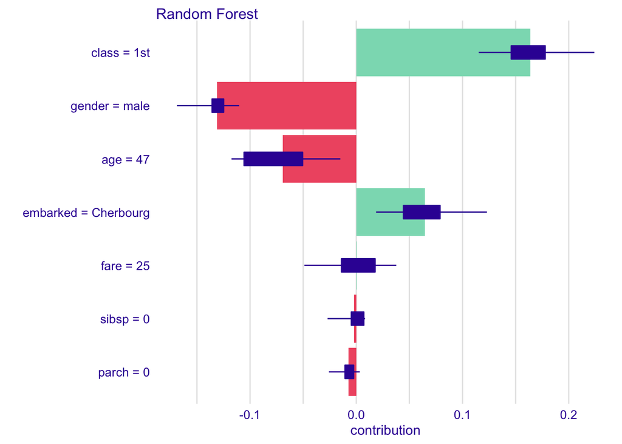

```r
plot(shap_henry)
```

- 箱ひげ図非表示

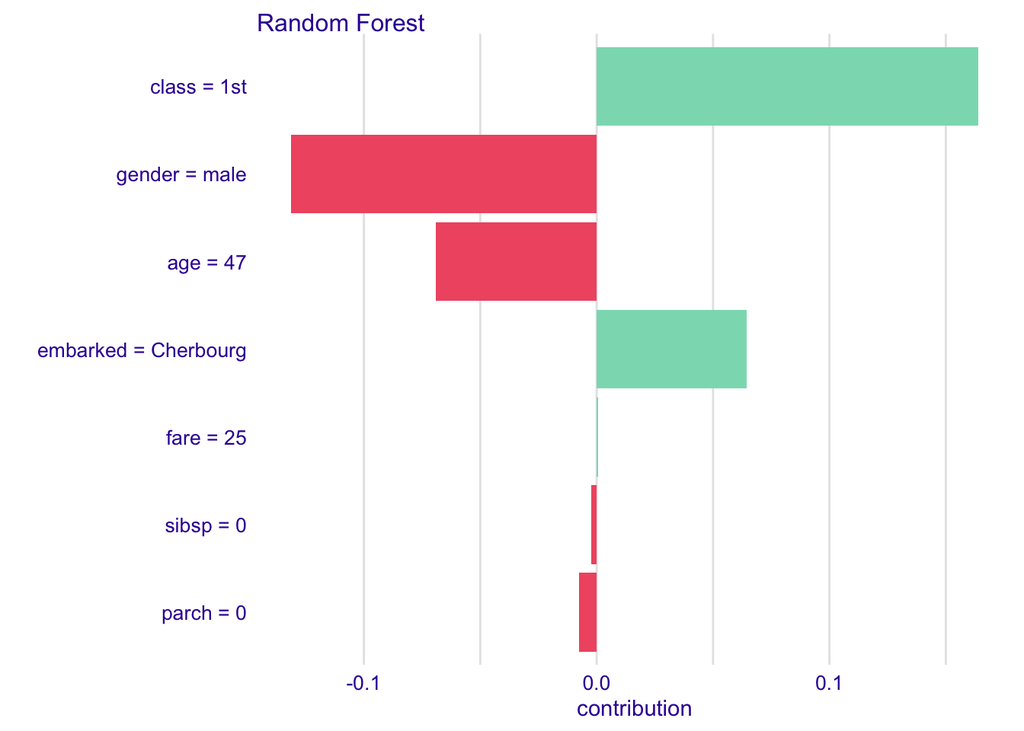

```r
plot(shap_henry, show_boxplots = FALSE)
```

# 10 Local Interpretable Model-agnostic Explanations (LIME)

## 10.6 Code snippets for R

### 10.6.1 The lime package

- 分類で使用することを明示し、randomForestでlime functionを作成

```r
library('lime')
model_type.randomForest <- function(x, ...) 'classification'
model_type.randomForest
```

```
## function(x, ...) 'classification'
```

- limeの計算に必要なobjectを作成
- johny_dのデータを使用

```r
lime_rf <- lime(titanic[, colnames(johny_d)], titanic_rf_v6)
lime_rf
```

```
## Model label:
## Model class:
## Data head  :
## NULL
```

- 説明オブジェクトを作成
- n_featuresでK-LASSOを指定（？？？？）、n_permutationsで人口データの数を指定

```r
lime_expl <- lime::explain(johny_d, lime_rf, labels = 'yes', n_features = 4, n_permutations = 1000)
lime_expl
```

```
## # A tibble: 4 x 13
##   model_type case  label label_prob model_r2 model_intercept model_prediction
##   <chr>      <chr> <chr>      <dbl>    <dbl>           <dbl>            <dbl>
## 1 classific… 1     yes        0.422    0.680           0.561            0.491
## 2 classific… 1     yes        0.422    0.680           0.561            0.491
## 3 classific… 1     yes        0.422    0.680           0.561            0.491
## 4 classific… 1     yes        0.422    0.680           0.561            0.491
## # … with 6 more variables: feature <chr>, feature_value <dbl>,
## #   feature_weight <dbl>, feature_desc <chr>, data <list>, prediction <list>
```

- 重要な特徴量をプロット

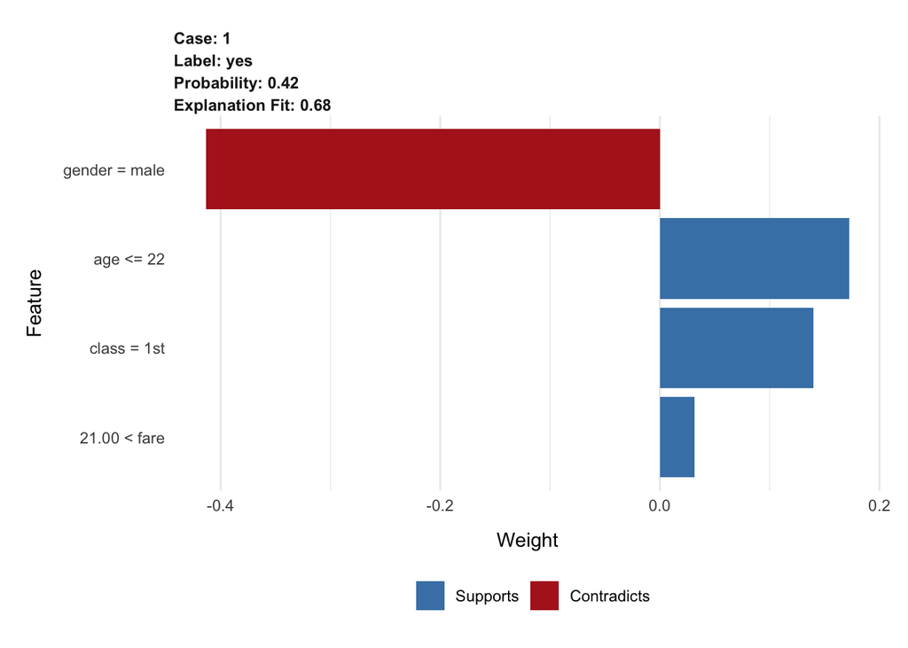

```r
plot_features(lime_expl)
```

### 10.6.2 The localModel package